# R Notebook

```r
library(DESeq2)
```

```r
library(ggplot2)
library(vsn)
library(pheatmap)
library(ggrepel)
library(ggpubr)

source("https://raw.githubusercontent.com/NUPulmonary/utils/master/R/plotPCA_manual.R")

source("https://github.com/NUPulmonary/utils/raw/master/R/go_enrichment.R")
```

Set random seed

```r
set.seed(1066)
```

```r
plot_lib_sizes <- function(data) {
    df <- data.frame(lib.size = sort(colSums(data)))
        ggplot(df, aes(x = reorder(rownames(df), lib.size), y = lib.size)) +
        geom_col() +
        ggtitle("Sorted library sizes") +
        theme(axis.text.x = element_text(angle = 90, vjust = .5, hjust = 1)) +
        xlab("")
}
```

# Nasal samples from CF

We have samples from 3 genotypes: Control, F508del homozygous and F508del heterozygous. We name them: control, F508del and CompHet respectively (compound heterozygotes).

Also we have 2 samples from universal human RNA as control samples.

Todo: 1. PCA analysis 2. DEGs between 3 groups with k-means clustering

### Load and preprocess data

```r
data <- read.table("Validation_cohort_raw_counts_relabeled_for_upload_with_genes.txt", header = TRUE)
```

Pick only samples

```r
coldata <- data.frame(row.names = colnames(data)[3:ncol(data)])
```

```r
rownames(coldata) <- sub("^X", "", rownames(coldata))
```

Prepare sample metadata: sample_type = sample / uhRNA genotype = uhRNA / control / F508del / CompHet

```r
coldata$sample_type <- "sample"
coldata$sample_type[grepl("uhrna", rownames(coldata))] <- "uhRNA"
```

```r
coldata$genotype <- "none"
coldata$genotype[grepl("uhrna", rownames(coldata))] <- "uhRNA"
coldata$genotype[grepl("Control", rownames(coldata))] <- "HV"
coldata$genotype[grepl("F508del", rownames(coldata))] <- "F508del"
coldata$genotype[grepl("CompHet", rownames(coldata))] <- "CompHet"
```

Separate counts

```r
counts <- as.matrix(data[, 3:ncol(data)])
colnames(counts) <- sub("^X", "", colnames(counts))
rownames(counts) <- data$Ensembl_ID
```

Now look! In the whole table there are no odd numbers! Isn’t it strange…

```r
sum(counts %% 2 == 1)
```

```
## [1] 0
```

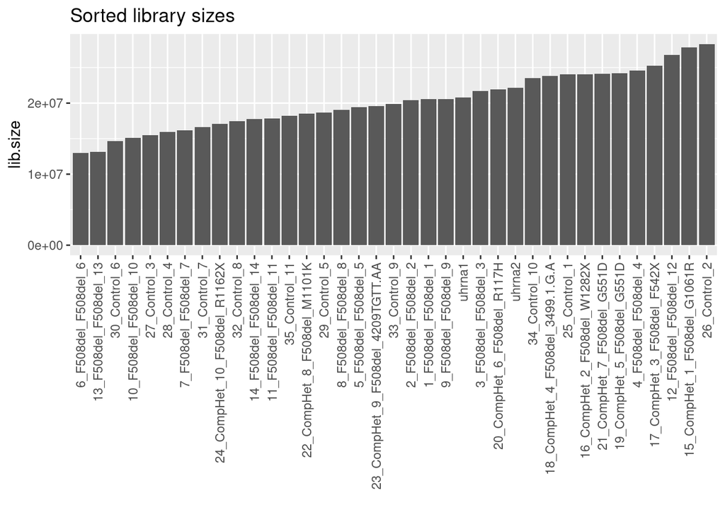

```r
plot_lib_sizes(counts / 2)
```

I’ll just divide all counts by 2 then

```r
dds <- DESeqDataSetFromMatrix(counts / 2, coldata, ~ genotype)
```

Add gene info

```r
rowData(dds) <- data[, 1:2]
```

```r
keep <- rowSums(counts(dds)) >= 10
dds <- dds[keep, ]
```

### Check quality and structure

Compute distances between samples

```r
sampleDists <- dist(t(assay(vst(dds))))
```

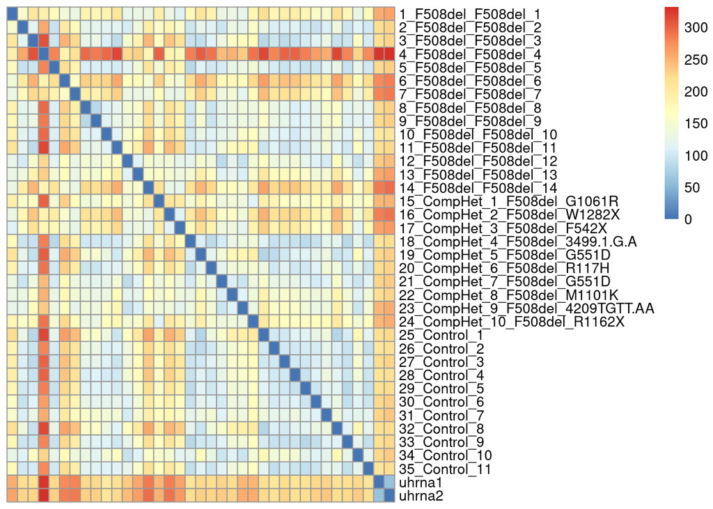

```r
pheatmap(as.matrix(sampleDists), cluster_cols = FALSE, cluster_rows = FALSE, show_colnames = FALSE)
```

uhRNA cluster together and different from everything else, good! Some structure visible in Control group, good. CompHet and F508del groups seem to be split between themselves.

Sample 4 seems to be an outlier.

Let’s plot PCA

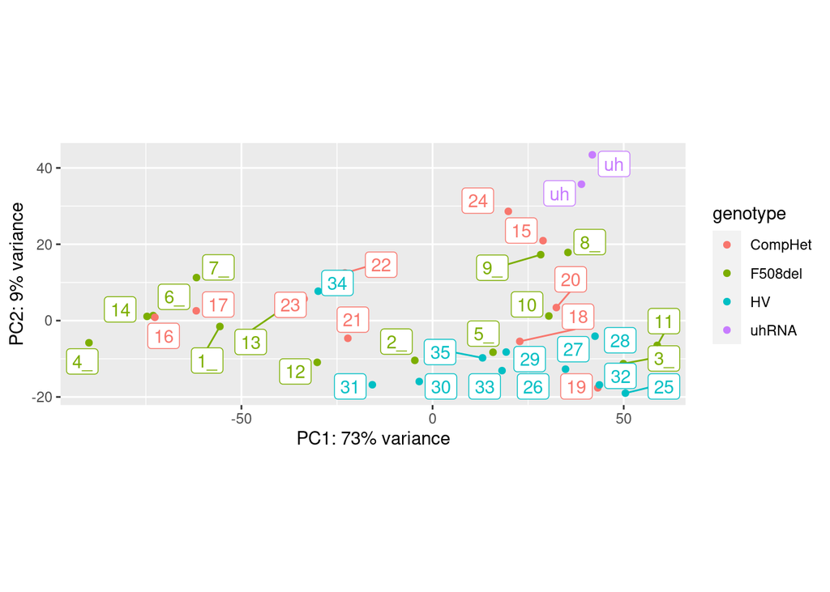

```r
d <- plotPCA(vst(dds), intgroup = c("genotype"), returnData = TRUE)
percentVar <- round(100 * attr(d, "percentVar"))

ggplot(d, aes(x = PC1, y = PC2, color = genotype)) +
  geom_point() +
  geom_label_repel(aes(label = sapply(colnames(dds), substr, 1, 2)), show.legend = FALSE) +
  xlab(paste0("PC1: ", percentVar[1], "% variance")) +
  ylab(paste0("PC2: ", percentVar[2], "% variance")) +
  coord_fixed()
```

uhRNA are together and a bit apart from everything else, good!. Sample 4 is on the left.

Let’s remove it and see what happens.

```r
counts2 <- counts[, -4]
coldata2 <- coldata[-4, ]
```

```r
dds <- DESeqDataSetFromMatrix(counts2 / 2, coldata2, ~ genotype)
rowData(dds) <- data[, 1:2]
```

```r
keep <- rowSums(counts(dds)) >= 10
dds <- dds[keep, ]
```

```r
sampleDists <- dist(t(assay(vst(dds))))
```

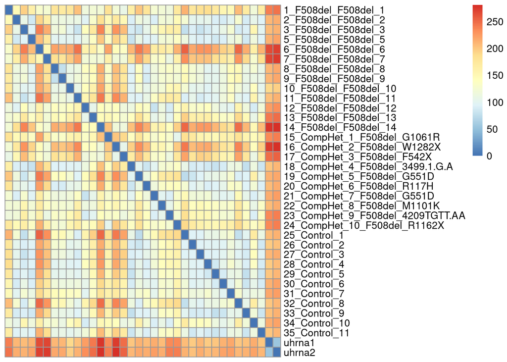

```r
pheatmap(as.matrix(sampleDists), cluster_cols = FALSE, cluster_rows = FALSE, show_colnames = FALSE)
```

Seems better.

Check PCA

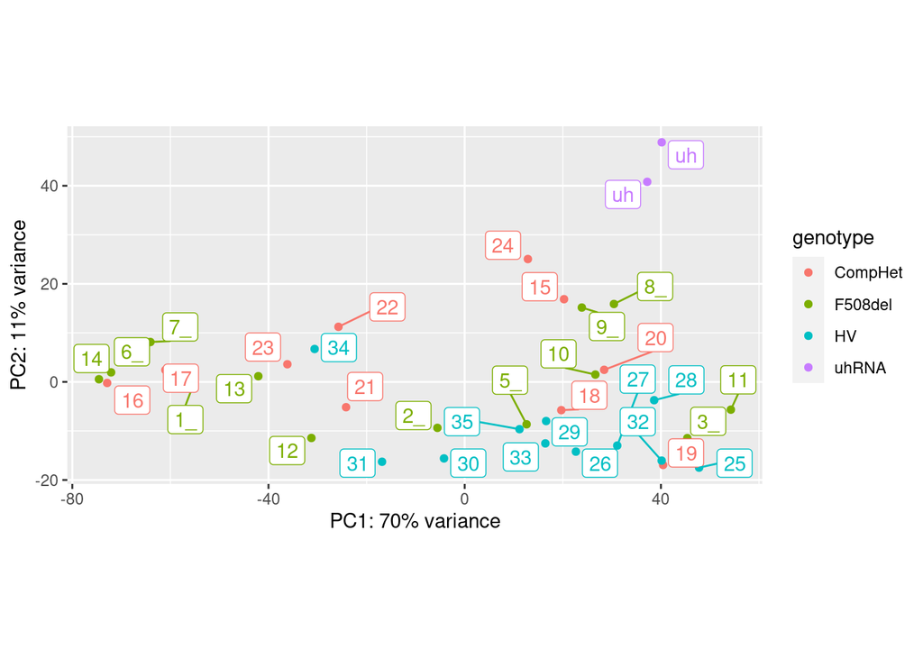

```r
d <- plotPCA(vst(dds), intgroup = c("genotype"), returnData = TRUE)
percentVar <- round(100 * attr(d, "percentVar"))

ggplot(d, aes(x = PC1, y = PC2, color = genotype)) +
  geom_point() +
  geom_label_repel(aes(label = sapply(colnames(dds), substr, 1, 2)), show.legend = FALSE) +
  xlab(paste0("PC1: ", percentVar[1], "% variance")) +
  ylab(paste0("PC2: ", percentVar[2], "% variance")) +
  coord_fixed()
```

A little bit better.

### Remove uhRNA samples and move to DEGs

```r
ncol(counts2)
```

```
## [1] 36
```

```r
counts3 <- counts2[, c(-35, -36)]
coldata3 <- coldata2[c(-35, -36), ]
```

```r
rownames(counts3) <- data$Ensembl_ID
```

```r
dds <- DESeqDataSetFromMatrix(counts3 / 2, coldata3, ~ genotype)
rowData(dds) <- data[, 1:2]
```

```r
keep <- rowSums(counts(dds)) >= 10
dds <- dds[keep, ]
```

```r
sampleDists <- dist(t(assay(vst(dds))))
```

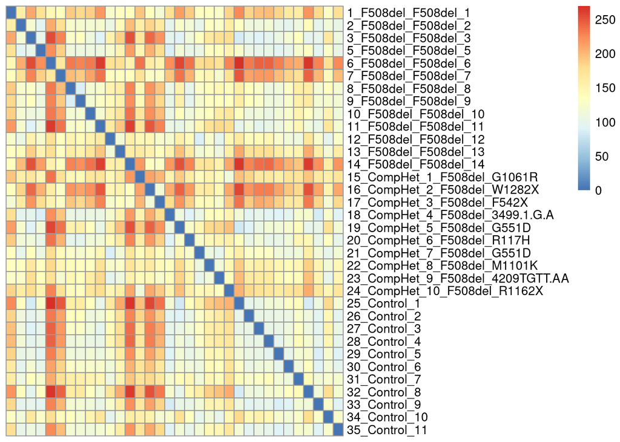

```r
pheatmap(as.matrix(sampleDists), cluster_cols = FALSE, cluster_rows = FALSE, show_colnames = FALSE)
```

Let’s see normalization methods

Log-norm

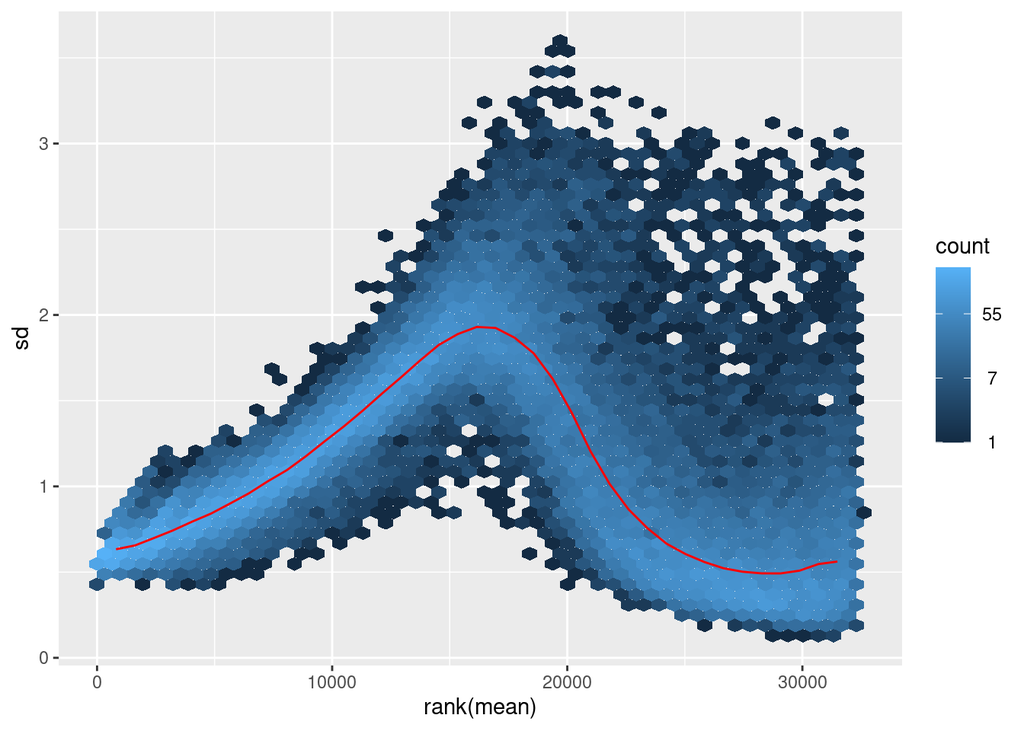

```r
meanSdPlot(assay(normTransform(dds)))
```

VST with parametric dispersions

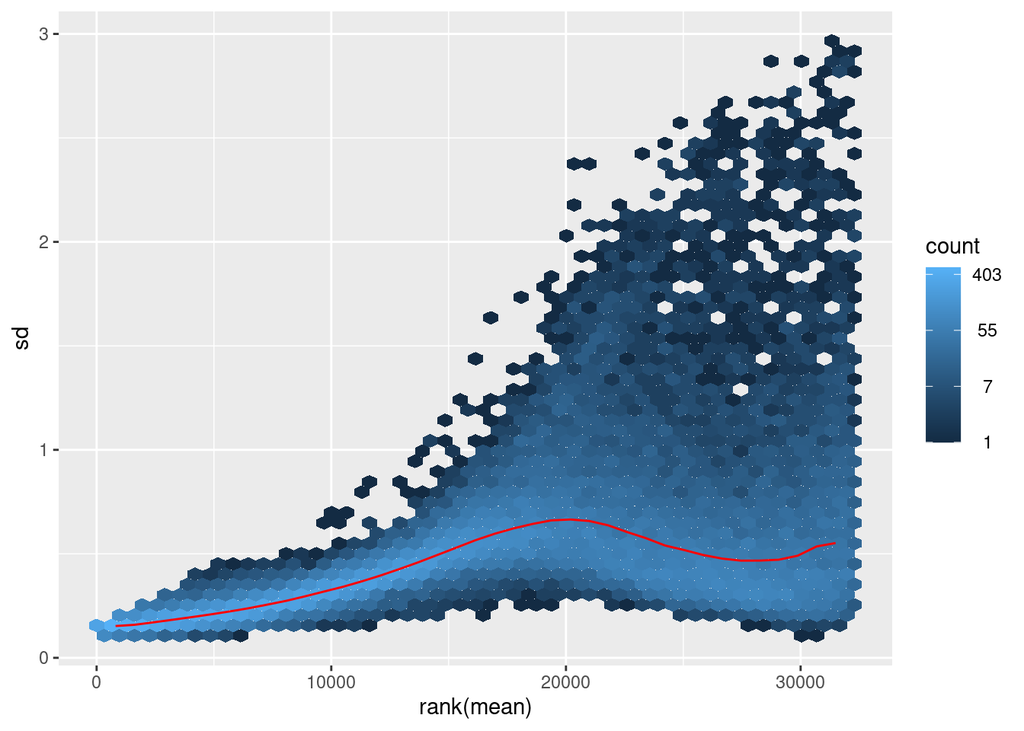

```r
meanSdPlot(assay(vst(dds, blind = FALSE)))
```

VST with local dispersions

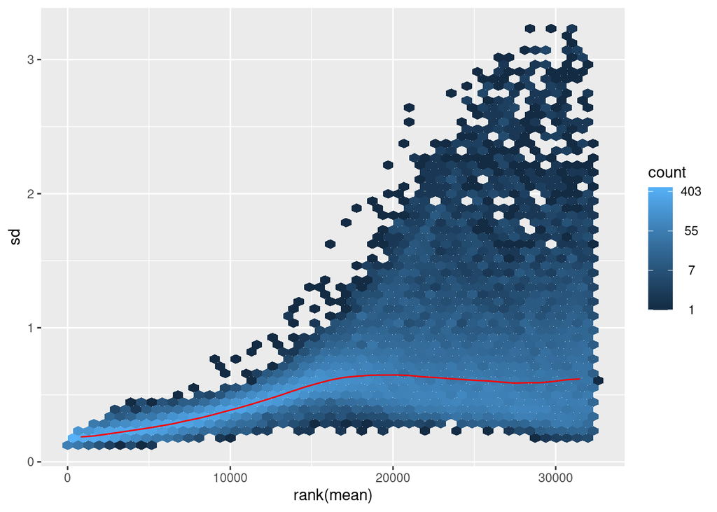

```r
meanSdPlot(assay(vst(dds, blind = FALSE, fitType = "local")))
```

Let’s use local dispersion estimations

PCA

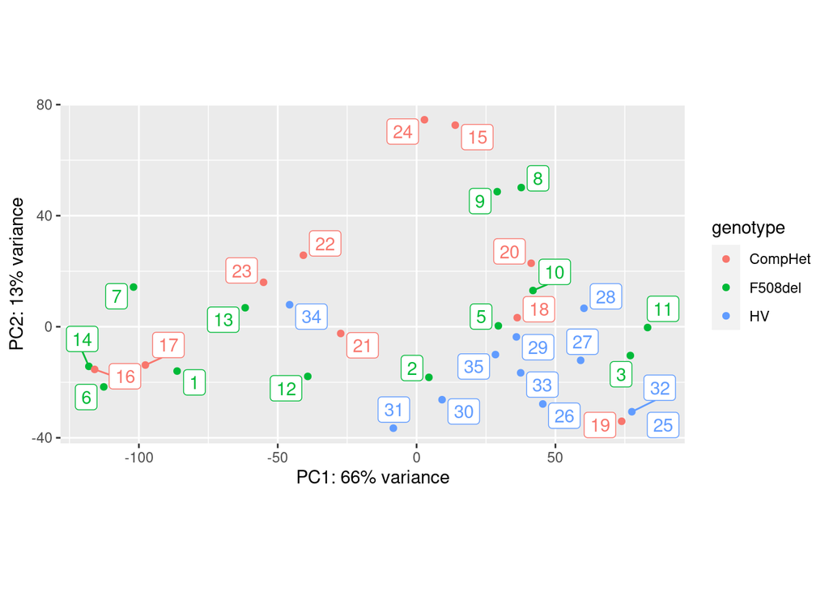

```r
d <- plotPCA(
  vst(dds, blind = FALSE, fitType = "local"),
  ntop = 2000,
  intgroup = c("genotype"),
  returnData = TRUE
)
percentVar <- round(100 * attr(d, "percentVar"))

ggplot(d, aes(x = PC1, y = PC2, color = genotype)) +
  geom_point() +
  geom_label_repel(aes(label = sapply(colnames(dds), function(x) {strsplit(x, "_")[[1]][1]})), show.legend = FALSE) +
  xlab(paste0("PC1: ", percentVar[1], "% variance")) +
  ylab(paste0("PC2: ", percentVar[2], "% variance")) +
  coord_fixed()
```

No clear structure. PC1 is most of variation, PC2 is much lower. Controls seem to be in lower right corner, while F508del and CompHet are spread out.

Save as PDF

```r
pdf("01pca.pdf", width=8, height=6)
ggplot(d, aes(x = PC1, y = PC2, color = genotype)) +
  geom_point() +
  geom_label_repel(aes(label = sapply(colnames(dds), function(x) {strsplit(x, "_")[[1]][1]})), show.legend = FALSE) +
  xlab(paste0("PC1: ", percentVar[1], "% variance")) +
  ylab(paste0("PC2: ", percentVar[2], "% variance")) +
  coord_fixed()
dev.off()
```

Let’s look at loadings of first PCs

```r
d <- plotPCA_manual(
  vst(dds, blind = FALSE, fitType = "local"),
  intgroup = c("genotype"),
  ntop = 2000,
  pcs = 10
)
percentVar <- round(100 * attr(d$data, "percentVar"))
```

```r
loadings <- data.frame(d$pca$rotation)
genes <- rownames(loadings)
gene_table <- rowData(dds)
for (i in 1:7) {
  print(sprintf("PC%d: %d %% variance", i, percentVar[i]))
  l <- loadings[, i]
  ord <- order(abs(l), decreasing = TRUE)
  g <- genes[ord][1:20]
  v <- paste(gene_table[g, "Gene_Name"], " (", round(l[ord][1:20], 4), ")")
  print(paste(v, collapse = ", "))
  print("=============")
}
```

```
## [1] "PC1: 66 % variance"
## [1] "PROK2  ( -0.048 ), FCGR3B  ( -0.0466 ), CXCR1  ( -0.0463 ), GPR65  ( -0.0462 ), BCL2A1  ( -0.046 ), OSM  ( -0.0459 ), MNDA  ( -0.0458 ), FPR2  ( -0.0457 ), MME  ( -0.0455 ), TNFRSF10C  ( -0.0454 ), FCAR  ( -0.0452 ), CXCR2  ( -0.0452 ), TREM1  ( -0.0452 ), SLC2A3  ( -0.0451 ), FFAR2  ( -0.04…
## [1] "============="
## [1] "PC2: 13 % variance"
## [1] "TPPP3  ( -0.0596 ), SPAG6  ( -0.0572 ), TUBA1A  ( -0.0572 ), FAM216B  ( -0.057 ), PIFO  ( -0.057 ), C20orf85  ( -0.0564 ), ROPN1L  ( -0.0554 ), FOXJ1  ( -0.0548 ), ZMYND10  ( -0.0542 ), OMG  ( -0.0537 ), CDHR3  ( -0.0532 ), SNTN  ( -0.0529 ), ERICH3  ( -0.0525 ), RSPH4A  ( -0.0522 ), DNAH9  …
## [1] "============="
## [1] "PC3: 5 % variance"
## [1] "CLDN17  ( 0.0836 ), LORICRIN  ( 0.082 ), DMKN  ( 0.0801 ), SPINK7  ( 0.0788 ), NDRG4  ( 0.0784 ), ASPRV1  ( 0.0753 ), CRCT1  ( 0.0751 ), CALB1  ( 0.0723 ), PNLIPRP3  ( 0.0722 ), ATG9B  ( 0.0682 ), SLC26A4  ( -0.068 ), SBSN  ( 0.0671 ), SLC26A4-AS1  ( -0.0669 ), RRAD  ( 0.0663 ), RNASE7  ( 0.…
## [1] "============="
## [1] "PC4: 2 % variance"
## [1] "KRT14  ( 0.1526 ), COL17A1  ( 0.1426 ), TNC  ( 0.1373 ), S100A2  ( 0.134 ), KRT5  ( 0.1239 ), FN1  ( 0.1085 ), COL7A1  ( 0.1038 ), LAMA3  ( 0.1013 ), PTHLH  ( 0.0963 ), TP63  ( 0.0947 ), CLCA2  ( 0.0938 ), DSG3  ( 0.0937 ), ITGA6  ( 0.0882 ), FST  ( 0.0873 ), KRT6B  ( 0.087 ), DSC3  ( 0.0866…
## [1] "============="
## [1] "PC5: 2 % variance"
## [1] "CXCL9  ( 0.1594 ), CXCL10  ( 0.1585 ), CXCL11  ( 0.1359 ), GBP5  ( 0.1161 ), SERPING1  ( 0.1119 ), GBP4  ( 0.1089 ), RSAD2  ( 0.1077 ), IFI6  ( 0.1003 ), GBP1  ( 0.0956 ), GZMB  ( 0.0936 ), IFI44L  ( 0.0919 ), IFIT1  ( 0.0918 ), CCL5  ( 0.0906 ), HLA-DOA  ( 0.0901 ), ISG15  ( 0.0877 ), CD8A …
## [1] "============="
## [1] "PC6: 1 % variance"
## [1] "FN1  ( -0.1162 ), COL3A1  ( -0.107 ), COL1A1  ( -0.0996 ), MMP9  ( -0.093 ), COL1A2  ( -0.0922 ), TNC  ( -0.0892 ), BPIFA1  ( -0.0862 ), CLEC12A  ( -0.0801 ), CAPN13  ( -0.0761 ), HBB  ( 0.0749 ), MMP2  ( -0.0746 ), CXCL13  ( -0.0739 ), RARRES1  ( -0.0709 ), AL365357.1  ( 0.0686 ), PXDN  ( -…
## [1] "============="
## [1] "PC7: 1 % variance"
## [1] "KRT24  ( -0.1111 ), LCE3D  ( 0.0995 ), MTND4P12  ( -0.0987 ), LCE3E  ( 0.0976 ), CXCL5  ( 0.0909 ), CD163  ( -0.0905 ), XIST  ( 0.0844 ), C1QC  ( -0.0841 ), SPRR2G  ( 0.082 ), MERTK  ( -0.0813 ), ANPEP  ( 0.0806 ), KPRP  ( 0.0776 ), SPRR2F  ( 0.0772 ), MMP10  ( 0.0735 ), STAB1  ( -0.0729 ), …
## [1] "============="
```

Let’s do K-means!

First, LRT between 3 conditions

```r
dds <- DESeq(dds, fitType = "local", test = "LRT", reduced = ~ 1)
```

```
## -- replacing outliers and refitting for 1788 genes
## -- DESeq argument 'minReplicatesForReplace' = 7
## -- original counts are preserved in counts(dds)
```

```r
deseq_results <- as.data.frame(results(dds))
```

Now select significant genes

```r
genes_of_interest <- rownames(subset(deseq_results, padj < 0.05))
```

```r
counts_mat_orig <- counts(dds, normalized = TRUE)
dds_orig <- dds
counts_mat <- counts_mat_orig[genes_of_interest, ]
```

```r
counts_mat <- t(scale(t(counts_mat)))
```

I tried 6, 4 and 3

```r
k <- 3
```

```r
kmeans_results <- as.data.frame(kmeans(x = counts_mat,
                          centers = k,
                          iter.max = 1000,
                          nstart = 500)$cluster)
```

```r
colnames(kmeans_results) <- "cluster"
```

```r
kmeans_results <- kmeans_results[order(kmeans_results$cluster), , drop = FALSE]
counts_mat <- counts_mat[rownames(kmeans_results), ]
```

```r
gaps <- cumsum(table(kmeans_results))[1:k]
```

```r
anno_col <- data.frame(colData(dds))[, c("genotype"), drop = FALSE]
```

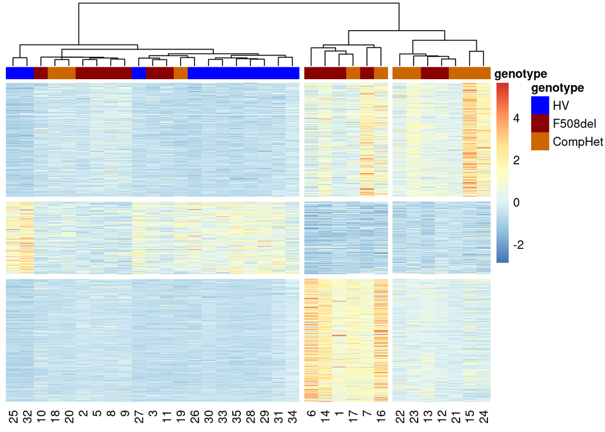

```r
plot <- pheatmap(counts_mat,
                  cluster_rows = FALSE,
                  cluster_cols = TRUE,
                  clustering_method = "ward.D2",
                  gaps_row = gaps,
                  show_colnames = TRUE,
                  show_rownames = FALSE,
                  labels_col = sapply(colnames(dds), function(x) {strsplit(x, "_")[[1]][1]}),
                  annotation_col = anno_col,
                  cutree_cols = 3,
                  border_color = NA,
                  angle_col = 90,
                  annotation_colors = list("genotype" = c(
                    "HV" = "blue",
                    "F508del" = "darkred",
                    "CompHet" = "darkorange3"
                  )))
```

Save as PDF

```r
pdf("02kmeans.pdf", width=8, height=6)
print(plot)
dev.off()
```

```r
write.csv(plot$tree_col$labels[plot$tree_col$order], "02kmeans-sample-order.csv")
```

```r
kmeans_genes <- deseq_results[rownames(kmeans_results),]
kmeans_genes$cluster <- kmeans_results[rownames(kmeans_genes), "cluster"]
```

Print top genes per cluster (lowest p-value)

```r
for (i in 1:k) {
  print(sprintf("K-means cluster %d (%d)", i, sum(kmeans_genes$cluster == i)))
  print("Lowest p-value genes")
  this <- kmeans_genes[kmeans_genes$cluster == i,]
  l <- this$padj
  ord <- order(l, decreasing = FALSE)
  g <- rownames(this)[ord][1:20]
  v <- paste(gene_table[g, "Gene_Name"], " (", round(l[ord][1:20], 4), ")")
  print(paste(v, collapse = ", "))
  print("=============")
}
```

```
## [1] "K-means cluster 1 (1045)"
## [1] "Lowest p-value genes"
## [1] "TENT5B  ( 0 ), MFAP3  ( 1e-04 ), TIMP3  ( 1e-04 ), ITGA2  ( 1e-04 ), RHOD  ( 1e-04 ), CYSRT1  ( 1e-04 ), MAF  ( 2e-04 ), NPC1  ( 2e-04 ), PITX1  ( 2e-04 ), MYO10  ( 3e-04 ), EMP1  ( 3e-04 ), PHLDA1  ( 3e-04 ), MT-TW  ( 3e-04 ), NAA50  ( 3e-04 ), B4GALT1  ( 3e-04 ), PLAT  ( 3e-04 ), CDCP1  ( …
## [1] "============="
## [1] "K-means cluster 2 (665)"
## [1] "Lowest p-value genes"
## [1] "FER1L4  ( 0 ), MTA1  ( 0 ), CDK10  ( 0 ), AHSA2P  ( 0 ), SGSM2  ( 0 ), PLEKHH1  ( 0 ), NKTR  ( 0 ), TTLL3  ( 0 ), RBM6  ( 0 ), SPG7  ( 1e-04 ), ICA1  ( 1e-04 ), TUBGCP6  ( 1e-04 ), GOLGA8A  ( 2e-04 ), CES3  ( 2e-04 ), GOLGA8B  ( 2e-04 ), SLC25A36  ( 2e-04 ), SLC25A29  ( 2e-04 ), AC010442.1  …
## [1] "============="
## [1] "K-means cluster 3 (1127)"
## [1] "Lowest p-value genes"
## [1] "RRAGC  ( 2e-04 ), FGFBP1  ( 4e-04 ), PHLDA2  ( 6e-04 ), EAF1  ( 7e-04 ), SMOX  ( 7e-04 ), MT-TL1  ( 7e-04 ), FXYD5  ( 7e-04 ), ANGPTL4  ( 8e-04 ), S100A10  ( 8e-04 ), CDKN1C  ( 9e-04 ), CLIC4  ( 9e-04 ), LYPD3  ( 9e-04 ), TSC22D3  ( 9e-04 ), PNP  ( 0.001 ), PPP1CB  ( 0.0011 ), PPBP  ( 0.0011…
## [1] "============="
```

Save the table

```r
kmeans_genes$gene_name <- gene_table[rownames(kmeans_genes), "Gene_Name"]
write.csv(kmeans_genes, "02kmeans-genes.csv")
```

Cut kmeans sample groups

```r
kmeans.groups <- cutree(plot$tree_col, k = 3)
```

```r
table(kmeans.groups)
```

```
## kmeans.groups
##  1  2  3
##  6 21  7
```

```r
group.names <- c("1" = "B", "2" = "A", "3" = "C")
```

```r
kmeans.samples <- group.names[kmeans.groups]
names(kmeans.samples) <- names(kmeans.groups)
write.csv(kmeans.samples, "02kmeans-sample-groups.csv")
```

Run GO enrichment for each cluster

```r
genes_cluster1 <- rownames(kmeans_genes)[kmeans_genes$cluster == 1]
go_cluster1 <- go_enrichment(dds_orig, genes_cluster1, go_annotations = "org.Hs.eg.db")
```

[output not shown]

[output not shown]

```
##  ( 12119 GO terms found. )
```

[output not shown]

```
##  ( 15904 GO terms and 37027 relations. )
```

[output not shown]

```
##  ( 16074 genes annotated to the GO terms. )
```

```
##
##           -- Classic Algorithm --
##
##       the algorithm is scoring 7256 nontrivial nodes
##       parameters:
##           test statistic: Fisher test
```

```r
genes_cluster2 <- rownames(kmeans_genes)[kmeans_genes$cluster == 2]
go_cluster2 <- go_enrichment(dds_orig, genes_cluster2, go_annotations = "org.Hs.eg.db")
```

[output not shown]

```
##  ( 12119 GO terms found. )
```

[output not shown]

```
##  ( 15904 GO terms and 37027 relations. )
```

[output not shown]

```
##  ( 16074 genes annotated to the GO terms. )
```

```
##
##           -- Classic Algorithm --
##
##       the algorithm is scoring 5284 nontrivial nodes
##       parameters:
##           test statistic: Fisher test
```

```r
genes_cluster3 <- rownames(kmeans_genes)[kmeans_genes$cluster == 3]
go_cluster3 <- go_enrichment(dds_orig, genes_cluster3, go_annotations = "org.Hs.eg.db")
```

[output not shown]

```
##  ( 12119 GO terms found. )
```

[output not shown]

```
##  ( 15904 GO terms and 37027 relations. )
```

[output not shown]

```
##  ( 16074 genes annotated to the GO terms. )
```

```
##
##           -- Classic Algorithm --
##
##       the algorithm is scoring 7861 nontrivial nodes
##       parameters:
##           test statistic: Fisher test
```

```r
go_cluster1$cluster <- 1
go_cluster2$cluster <- 2
go_cluster3$cluster <- 3
```

```r
go_processes <- rbind(go_cluster1, go_cluster2, go_cluster3)
```

```r
write.csv(go_processes, "02kmeans-go-processes.csv")
```

## Pairwise comparisons

k-means and deconvolution both identified three groups of samples: “epithelium-rich” cluster, containing controls, CF and heterozygotes, and two immune clusters, mostly containing CF and hets.

Let’s run pairwise DEGs between 1) controls vs CF, 2) control vs hets, 3) CF vs hets using all samples.

```r
dds <- DESeq(dds, fitType = "local")
```

```
## found already estimated dispersions, replacing these
```

```
## -- replacing outliers and refitting for 1766 genes
## -- DESeq argument 'minReplicatesForReplace' = 7
## -- original counts are preserved in counts(dds)
```

### Control vs CF

```r
ctrl.vs.cf <- as.data.frame(results(dds, contrast = c("genotype", "HV", "F508del")))
ctrl.vs.cf <- ctrl.vs.cf[!is.na(ctrl.vs.cf$padj), ]
ctrl.vs.cf$sign <- ""
ctrl.vs.cf$sign[(ctrl.vs.cf$log2FoldChange < 0) & (ctrl.vs.cf$padj < 0.05)] <- "Downregulated"
ctrl.vs.cf$sign[(ctrl.vs.cf$log2FoldChange > 0) & (ctrl.vs.cf$padj < 0.05)] <- "Upregulated"
ctrl.vs.cf <- ctrl.vs.cf[order(ctrl.vs.cf$sign),]
```

```r
ace2_id <- gene_table$Ensembl_ID[gene_table$Gene_Name %in% c("ACE2", "TMPRSS2")]
```

```r
ace2_data <- as.data.frame(merge(ctrl.vs.cf[ace2_id, ], gene_table[ace2_id, ], by = "row.names"))
```

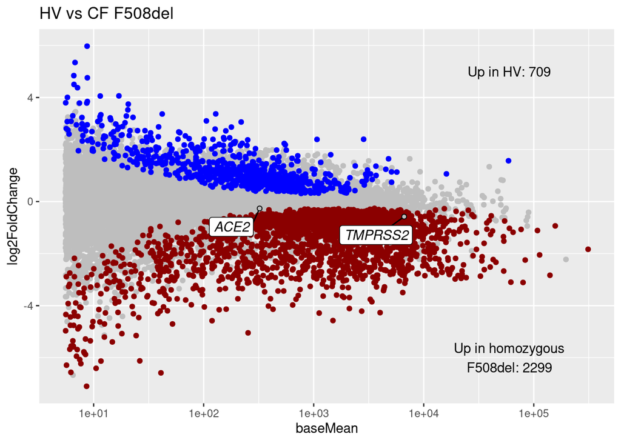

```r
ggplot(ctrl.vs.cf, aes(x = baseMean, y = log2FoldChange)) +
  geom_point(aes(fill = sign, color = sign), shape = 21, stroke = 0.5) +
  geom_label_repel(
    aes(label = Gene_Name, fontface = "italic"),
    data = ace2_data,
    box.padding = 0.5,
    seed = 5000,
  ) +
  geom_point(aes(fill = sign), data = ace2_data, stroke = 0.5, shape = 21) +
  scale_x_log10() +
  scale_color_manual(values = c("gray", "darkred", "blue"), name = "Significance", labels = c("Not significant", "Downregulated", "Upregulated")) +
  scale_fill_manual(values = c("gray", "darkred", "blue"), name = "Significance", labels = c("Not significant", "Downregulated", "Upregulated")) +
  annotate("text", x = 6e+04, y = 5, label = sprintf("Up in HV: %d", sum(ctrl.vs.cf$sign == "Upregulated"))) +
  annotate("text", x = 6e+04, y = -6, label = sprintf("Up in homozygous\nF508del: %d", sum(ctrl.vs.cf$sign == "Downregulated"))) +
  ggtitle("HV vs CF F508del") +
  theme(legend.position = "none")
```

Save as PDF

```r
pdf("03control-vs-f508del.pdf", width=6, height = 6)
ggplot(ctrl.vs.cf, aes(x = baseMean, y = log2FoldChange)) +
  geom_point(aes(fill = sign, color = sign), shape = 21, stroke = 0.5) +
  geom_label_repel(
    aes(label = Gene_Name, fontface = "italic"),
    data = ace2_data,
    box.padding = 0.5,
    seed = 5000,
  ) +
  geom_point(aes(fill = sign), data = ace2_data, stroke = 0.5, shape = 21) +
  scale_x_log10() +
  scale_color_manual(values = c("gray", "darkred", "blue"), name = "Significance", labels = c("Not significant", "Downregulated", "Upregulated")) +
  scale_fill_manual(values = c("gray", "darkred", "blue"), name = "Significance", labels = c("Not significant", "Downregulated", "Upregulated")) +
  annotate("text", x = 6e+04, y = 5, label = sprintf("Up in HV: %d", sum(ctrl.vs.cf$sign == "Upregulated"))) +
  annotate("text", x = 6e+04, y = -6, label = sprintf("Up in homozygous\nF508del: %d", sum(ctrl.vs.cf$sign == "Downregulated"))) +
  ggtitle("HV vs CF F508del") +
  theme(legend.position = "none")
dev.off()
```

Let’s verify the sign. Select most expressed upregulated gene

```r
upreg <- ctrl.vs.cf[ctrl.vs.cf$log2FoldChange > 0,]
upreg[order(upreg$baseMean, decreasing = TRUE), ][1:5, ]
```

|  | baseMean | log2FoldChange | lfcSE | stat | pvalue | padj | sign |
| --- | --- | --- | --- | --- | --- | --- | --- |
| ENSG00000215182 | 58941.92 | 1.5685634 | 0.5615403 | 2.7933232 | 0.005216954 | 0.03798446 | Upregulated |
| ENSG00000198183 | 52472.46 | 0.8180361 | 0.6219239 | 1.3153314 | 0.188398542 | 0.35669323 |  |
| ENSG00000162896 | 50604.89 | 0.8344669 | 0.4562411 | 1.8290043 | 0.067398958 | 0.18616926 |  |
| ENSG00000101443 | 50018.73 | 0.1105185 | 0.2522242 | 0.4381755 | 0.661259099 | 0.79340530 |  |
| ENSG00000148346 | 47147.73 | 0.3969240 | 0.3391727 | 1.1702712 | 0.241891863 | 0.42045993 |  |

```r
expr.df <- coldata3
expr.df$MUC5AC <- counts_mat_orig[rownames(gene_table)[gene_table$Gene_Name == "MUC5AC"], ]
```

And plot it by genotype

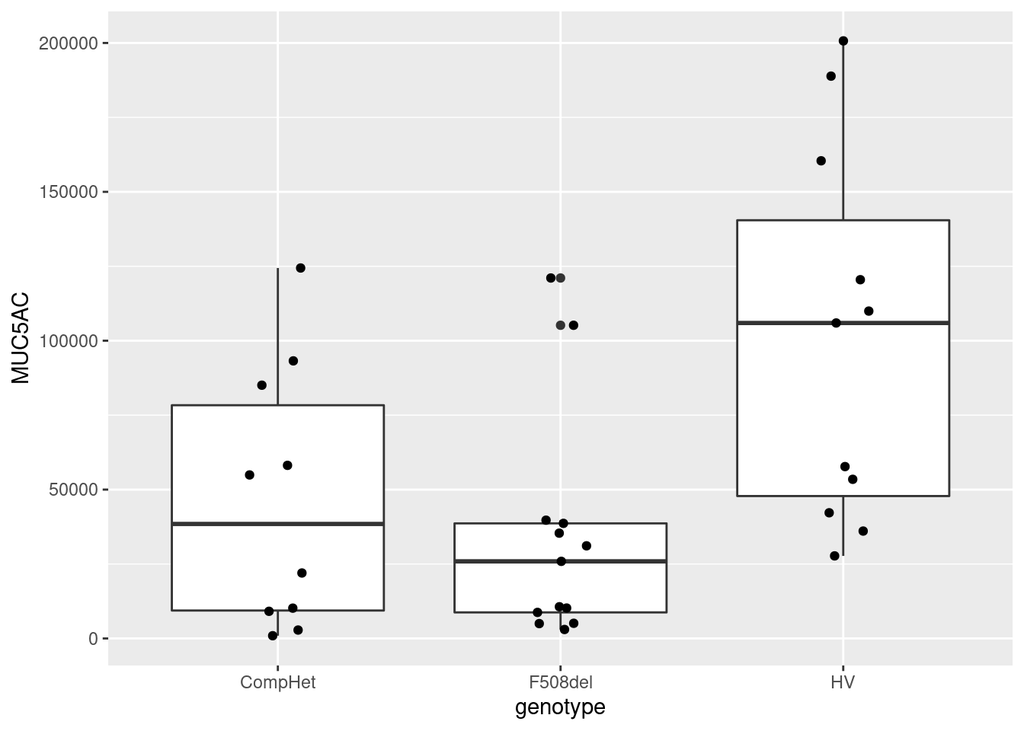

```r
ggplot(expr.df) + geom_boxplot(aes(x = genotype, y = MUC5AC)) +
  geom_jitter(aes(x = genotype, y = MUC5AC), height = 0, width = 0.1)
```

The sign is correct. Let’s save results

```r
sign.only <- ctrl.vs.cf[ctrl.vs.cf$padj < 0.05, ]
sign.only$gene_name <- gene_table[rownames(sign.only), "Gene_Name"]
write.csv(sign.only[order(sign.only$log2FoldChange, decreasing = TRUE), ], "03ctrl-vs-cf.csv")
```

Here in control we see T cell signature (CD8A, CD3E etc), but it’s not picked up by deconvolution.

### Illustrate k-means cluster composition bias

```r
ciliated_secr_markers <- c("CAPS", "TPPP3", "BPIFA1")
cil.df <- expr.df
cil.df$MUC5AC <- NULL
cil.df$cluster <- group.names[kmeans.groups]
cil.df$cluster <- factor(cil.df$cluster, levels=c("A", "B", "C"))

for (g in ciliated_secr_markers) {
  cil.df[[g]] <- counts_mat_orig[rownames(gene_table)[gene_table$Gene_Name == g], ]
}

cil.df.long <- cil.df %>%
  tidyr::pivot_longer(ciliated_secr_markers, names_to = "gene")
```

```
## Note: Using an external vector in selections is ambiguous.
## ℹ Use `all_of(ciliated_secr_markers)` instead of `ciliated_secr_markers` to silence this message.
## ℹ See <https://tidyselect.r-lib.org/reference/faq-external-vector.html>.
```

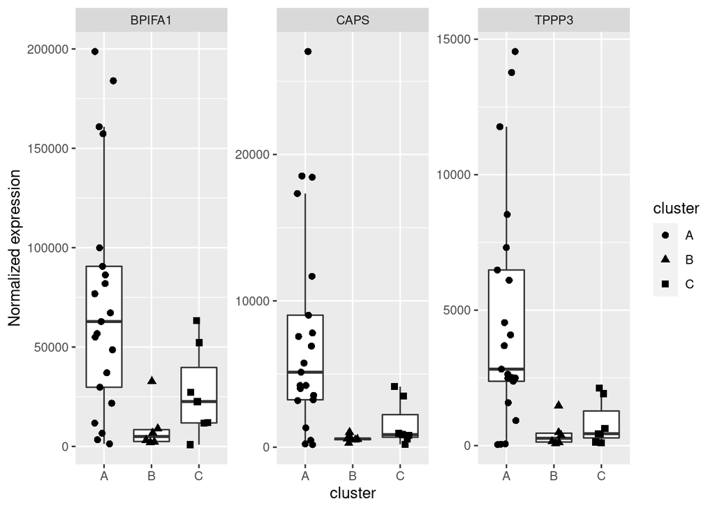

```r
ggplot(cil.df.long) + geom_boxplot(aes(x = cluster, y = value), outlier.shape = NA) +
  geom_jitter(aes(x = cluster, y = value, shape = cluster), height = 0, width = 0.2, size = 2) +
  facet_wrap(vars(gene), scales = "free_y") +
  ylab("Normalized expression")
```

Save as PDF

```r
pdf("02kmeans-ciliated.pdf", width = 6, height = 3)
ciliated_secr_markers <- c("CAPS", "TPPP3", "BPIFA1")
cil.df <- expr.df
cil.df$MUC5AC <- NULL
cil.df$cluster <- group.names[kmeans.groups]
cil.df$cluster <- factor(cil.df$cluster, levels=c("A", "B", "C"))

for (g in ciliated_secr_markers) {
  cil.df[[g]] <- counts_mat_orig[rownames(gene_table)[gene_table$Gene_Name == g], ]
}

cil.df.long <- cil.df %>%
  tidyr::pivot_longer(ciliated_secr_markers, names_to = "gene")

ggplot(cil.df.long) + geom_boxplot(aes(x = cluster, y = value), outlier.shape = NA) +
  geom_jitter(aes(x = cluster, y = value, shape = cluster), height = 0, width = 0.2, size = 2) +
  facet_wrap(vars(gene), scales = "free_y") +
  ylab("Normalized expression")
dev.off()
```

```r
immune_markers <- c("CSF3R", "FCGR3B", "ITGA2")
imm.df <- expr.df
imm.df$MUC5AC <- NULL
imm.df$cluster <- group.names[kmeans.groups]
imm.df$cluster <- factor(imm.df$cluster, levels=c("A", "B", "C"))

for (g in immune_markers) {
  imm.df[[g]] <- counts_mat_orig[rownames(gene_table)[gene_table$Gene_Name == g], ]
}

imm.df.long <- imm.df %>%
  tidyr::pivot_longer(immune_markers, names_to = "gene")
```

```
## Note: Using an external vector in selections is ambiguous.
## ℹ Use `all_of(immune_markers)` instead of `immune_markers` to silence this message.
## ℹ See <https://tidyselect.r-lib.org/reference/faq-external-vector.html>.
```

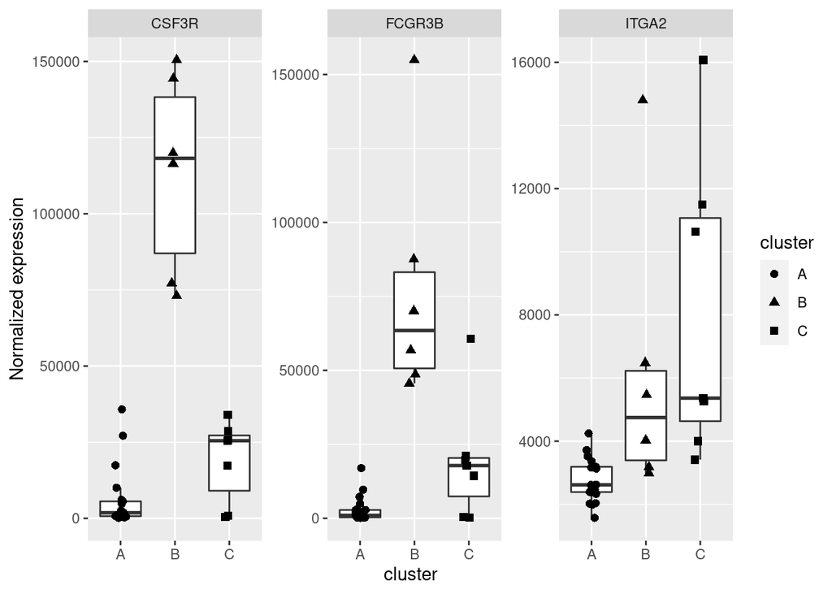

```r
ggplot(imm.df.long) + geom_boxplot(aes(x = cluster, y = value), outlier.shape = NA) +
  geom_jitter(aes(x = cluster, y = value, shape = cluster), height = 0, width = 0.1, size = 2) +
  facet_wrap(vars(gene), scales = "free_y") +
  ylab("Normalized expression")
```

Save as PDF

```r
pdf("02kmeans-immune.pdf", width = 6, height = 3)
immune_markers <- c("CSF3R", "FCGR3B", "ITGA2")
imm.df <- expr.df
imm.df$MUC5AC <- NULL
imm.df$cluster <- group.names[kmeans.groups]
imm.df$cluster <- factor(imm.df$cluster, levels=c("A", "B", "C"))

for (g in immune_markers) {
  imm.df[[g]] <- counts_mat_orig[rownames(gene_table)[gene_table$Gene_Name == g], ]
}

imm.df.long <- imm.df %>%
  tidyr::pivot_longer(immune_markers, names_to = "gene")

ggplot(imm.df.long) + geom_boxplot(aes(x = cluster, y = value), outlier.shape = NA) +
  geom_jitter(aes(x = cluster, y = value, shape = cluster), height = 0, width = 0.1, size = 2) +
  facet_wrap(vars(gene), scales = "free_y") +
  ylab("Normalized expression")
dev.off()
```

### Control vs CompHet

```r
ctrl.vs.het <- as.data.frame(results(dds, contrast = c("genotype", "HV", "CompHet")))
ctrl.vs.het <- ctrl.vs.het[!is.na(ctrl.vs.het$padj), ]
ctrl.vs.het$sign <- ""
ctrl.vs.het$sign[(ctrl.vs.het$log2FoldChange < 0) & (ctrl.vs.het$padj < 0.05)] <- "Downregulated"
ctrl.vs.het$sign[(ctrl.vs.het$log2FoldChange > 0) & (ctrl.vs.het$padj < 0.05)] <- "Upregulated"
ctrl.vs.het <- ctrl.vs.het[order(ctrl.vs.het$sign),]
```

```r
ace2_data <- as.data.frame(merge(ctrl.vs.het[ace2_id, ], gene_table[ace2_id, ], by = "row.names"))
```

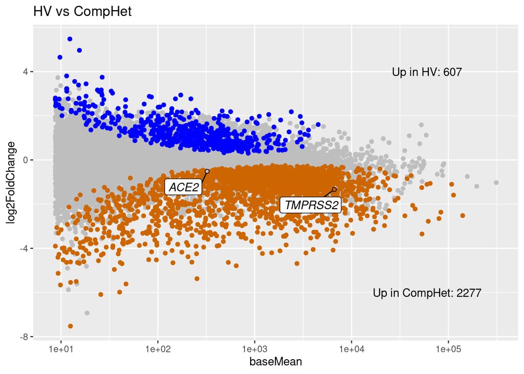

```r
ggplot(ctrl.vs.het, aes(x = baseMean, y = log2FoldChange)) +
  geom_point(aes(fill = sign, color = sign), shape = 21, stroke = 0.5) +
  geom_label_repel(
    aes(label = Gene_Name, fontface = "italic"),
    data = ace2_data,
    box.padding = 0.5,
    seed = 5000,
  ) +
  geom_point(aes(fill = sign), data = ace2_data, stroke = 0.5, shape = 21) +
  scale_x_log10() +
  scale_color_manual(values = c("gray", "darkorange3", "blue"), name = "Significance", labels = c("Not significant", "Downregulated", "Upregulated")) +
  scale_fill_manual(values = c("gray", "darkorange3", "blue"), name = "Significance", labels = c("Not significant", "Downregulated", "Upregulated")) +
  annotate("text", x = 6e+04, y = 4, label = sprintf("Up in HV: %d", sum(ctrl.vs.het$sign == "Upregulated"))) +
  annotate("text", x = 6e+04, y = -6, label = sprintf("Up in CompHet: %d", sum(ctrl.vs.het$sign == "Downregulated"))) +
  ggtitle("HV vs CompHet") +
  theme(legend.position = "none")
```

Save as PDF

```r
pdf("03control-vs-comphet.pdf", width=6, height=6)
ggplot(ctrl.vs.het, aes(x = baseMean, y = log2FoldChange)) +
  geom_point(aes(fill = sign, color = sign), shape = 21, stroke = 0.5) +
  geom_label_repel(
    aes(label = Gene_Name, fontface = "italic"),
    data = ace2_data,
    box.padding = 0.5,
    seed = 5000,
  ) +
  geom_point(aes(fill = sign), data = ace2_data, stroke = 0.5, shape = 21) +
  scale_x_log10() +
  scale_color_manual(values = c("gray", "darkorange3", "blue"), name = "Significance", labels = c("Not significant", "Downregulated", "Upregulated")) +
  scale_fill_manual(values = c("gray", "darkorange3", "blue"), name = "Significance", labels = c("Not significant", "Downregulated", "Upregulated")) +
  annotate("text", x = 6e+04, y = 4, label = sprintf("Up in HV: %d", sum(ctrl.vs.het$sign == "Upregulated"))) +
  annotate("text", x = 6e+04, y = -6, label = sprintf("Up in CompHet: %d", sum(ctrl.vs.het$sign == "Downregulated"))) +
  ggtitle("HV vs CompHet") +
  theme(legend.position = "none")
dev.off()
```

```r
sign.only <- ctrl.vs.het[ctrl.vs.het$padj < 0.05, ]
sign.only$gene_name <- gene_table[rownames(sign.only), "Gene_Name"]
write.csv(sign.only[order(sign.only$log2FoldChange, decreasing = TRUE), ], "03ctrl-vs-het.csv")
```

### CompHet vs CF

```r
het.vs.cf <- as.data.frame(results(dds, contrast = c("genotype", "CompHet", "F508del")))
het.vs.cf <- het.vs.cf[!is.na(het.vs.cf$padj), ]
het.vs.cf$sign <- ""
het.vs.cf$sign[(het.vs.cf$log2FoldChange < 0) & (het.vs.cf$padj < 0.05)] <- "Downregulated"
het.vs.cf$sign[(het.vs.cf$log2FoldChange > 0) & (het.vs.cf$padj < 0.05)] <- "Upregulated"
het.vs.cf <- het.vs.cf[order(het.vs.cf$sign),]
```

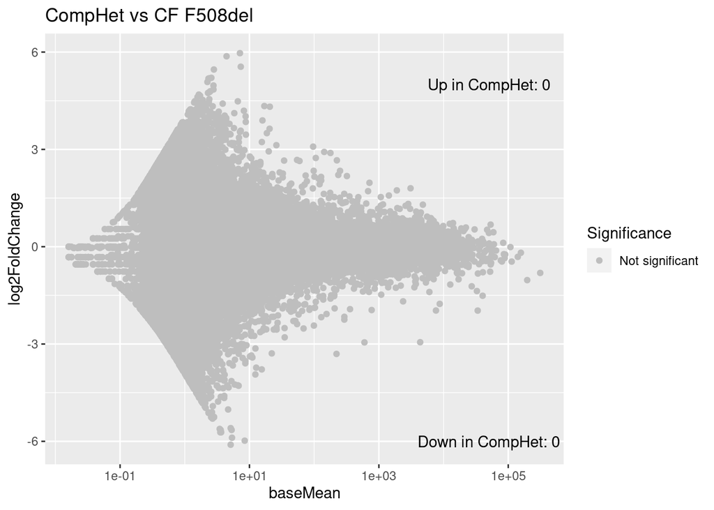

```r
ggplot(het.vs.cf) +
  geom_point(aes(x = baseMean, y = log2FoldChange, col = sign)) +
  scale_x_log10() +
  scale_color_manual(values = c("gray", "red", "blue"), name = "Significance", labels = c("Not significant", "Downregulated", "Upregulated")) +
  annotate("text", x = 5e+04, y = 5, label = sprintf("Up in CompHet: %d", sum(het.vs.cf$sign == "Upregulated"))) +
  annotate("text", x = 5e+04, y = -6, label = sprintf("Down in CompHet: %d", sum(het.vs.cf$sign == "Downregulated"))) +
  ggtitle("CompHet vs CF F508del")
```

No DEGs here!

Save as PDF

```r
pdf("03comphet-vs-f508del.pdf", width=8, height=6)
ggplot(het.vs.cf) +
  geom_point(aes(x = baseMean, y = log2FoldChange, col = sign)) +
  scale_x_log10() +
  scale_color_manual(values = c("gray", "red", "blue"), name = "Significance", labels = c("Not significant", "Downregulated", "Upregulated")) +
  annotate("text", x = 5e+04, y = 5, label = sprintf("Up in CompHet: %d", sum(het.vs.cf$sign == "Upregulated"))) +
  annotate("text", x = 5e+04, y = -6, label = sprintf("Down in CompHet: %d", sum(het.vs.cf$sign == "Downregulated"))) +
  ggtitle("CompHet vs CF F508del")
dev.off()
```

## Pairwise comparisons within same k-means cluster

Then let’s run this comparison using samples from “epithelial” cluster only, which we define by deconvolution

```r
epi.samples <- names(kmeans.groups[kmeans.groups == 2])
```

```r
epi.counts <- counts[, epi.samples]
epi.coldata <- coldata[epi.samples, ]
dds <- DESeqDataSetFromMatrix(epi.counts / 2, epi.coldata, ~ genotype)
dds <- DESeq(dds, fitType = "local")
```

```
## -- replacing outliers and refitting for 678 genes
## -- DESeq argument 'minReplicatesForReplace' = 7
## -- original counts are preserved in counts(dds)
```

### Control vs CF

```r
ctrl.vs.cf <- as.data.frame(results(dds, contrast = c("genotype", "HV", "F508del")))
ctrl.vs.cf <- ctrl.vs.cf[!is.na(ctrl.vs.cf$padj), ]
ctrl.vs.cf$sign <- ""
ctrl.vs.cf$sign[(ctrl.vs.cf$log2FoldChange < 0) & (ctrl.vs.cf$padj < 0.05)] <- "Downregulated"
ctrl.vs.cf$sign[(ctrl.vs.cf$log2FoldChange > 0) & (ctrl.vs.cf$padj < 0.05)] <- "Upregulated"
ctrl.vs.cf <- ctrl.vs.cf[order(ctrl.vs.cf$sign),]
```

```r
ace2_data <- as.data.frame(merge(ctrl.vs.cf[ace2_id, ], gene_table[ace2_id, ], by = "row.names", suffixes = c("", ".y")))
```

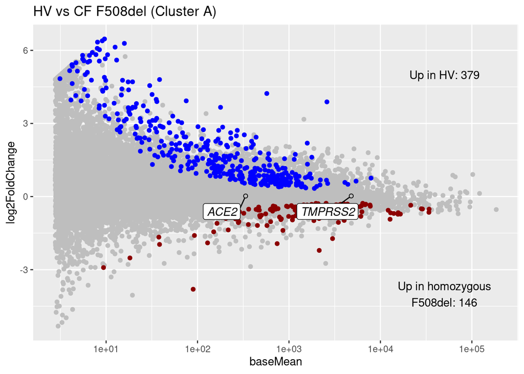

```r
ggplot(ctrl.vs.cf, aes(x = baseMean, y = log2FoldChange)) +
  geom_point(aes(fill = sign, color = sign), shape = 21, stroke = 0.5) +
    geom_label_repel(
    aes(label = Gene_Name, fontface = "italic"),
    data = ace2_data,
    box.padding = 0.5,
    seed = 5000,
  ) +
  geom_point(aes(fill = sign), data = ace2_data, stroke = 0.5, shape = 21) +
  scale_x_log10() +
  scale_color_manual(values = c("gray", "darkred", "blue"), name = "Significance", labels = c("Not significant", "Downregulated", "Upregulated")) +
  scale_fill_manual(values = c("gray", "darkred", "blue"), name = "Significance", labels = c("Not significant", "Downregulated", "Upregulated")) +
  annotate("text", x = 5e+04, y = 5, label = sprintf("Up in HV: %d", sum(ctrl.vs.cf$sign == "Upregulated"))) +
  annotate("text", x = 5e+04, y = -4, label = sprintf("Up in homozygous\nF508del: %d", sum(ctrl.vs.cf$sign == "Downregulated"))) +
  ggtitle("HV vs CF F508del (Cluster A)") +
  theme(legend.position = "none")
```

Save as PDF

```r
pdf("04epi-samples-control-vs-f508del.pdf", width=6, height=6)
ggplot(ctrl.vs.cf, aes(x = baseMean, y = log2FoldChange)) +
  geom_point(aes(fill = sign, color = sign), shape = 21, stroke = 0.5) +
    geom_label_repel(
    aes(label = Gene_Name, fontface = "italic"),
    data = ace2_data,
    box.padding = 0.5,
    seed = 5000,
  ) +
  geom_point(aes(fill = sign), data = ace2_data, stroke = 0.5, shape = 21) +
  scale_x_log10() +
  scale_color_manual(values = c("gray", "darkred", "blue"), name = "Significance", labels = c("Not significant", "Downregulated", "Upregulated")) +
  scale_fill_manual(values = c("gray", "darkred", "blue"), name = "Significance", labels = c("Not significant", "Downregulated", "Upregulated")) +
  annotate("text", x = 5e+04, y = 5, label = sprintf("Up in HV: %d", sum(ctrl.vs.cf$sign == "Upregulated"))) +
  annotate("text", x = 5e+04, y = -4, label = sprintf("Up in homozygous\nF508del: %d", sum(ctrl.vs.cf$sign == "Downregulated"))) +
  ggtitle("HV vs CF F508del (Cluster A)") +
  theme(legend.position = "none")
dev.off()
```

```r
sign.only <- ctrl.vs.cf[ctrl.vs.cf$padj < 0.05, ]
sign.only$gene_name <- gene_table[rownames(sign.only), "Gene_Name"]
write.csv(sign.only[order(sign.only$log2FoldChange, decreasing = TRUE), ], "04epi-ctrl-vs-cf.csv")
```

Query GO processes for up- and down-regulated genes here

```r
upreg_genes <- rownames(sign.only)[sign.only$sign == "Upregulated"]
go_upreg <- go_enrichment(dds, upreg_genes, go_annotations = "org.Hs.eg.db")
```

```
##
## Building most specific GOs .....
```

```
##  ( 12175 GO terms found. )
```

```
##
## Build GO DAG topology ..........
```

```
##  ( 15946 GO terms and 37138 relations. )
```

```
##
## Annotating nodes ...............
```

```
##  ( 16473 genes annotated to the GO terms. )
```

```
##
##           -- Classic Algorithm --
##
##       the algorithm is scoring 4042 nontrivial nodes
##       parameters:
##           test statistic: Fisher test
```

```r
downreg_genes <- rownames(sign.only)[sign.only$sign == "Downregulated"]
go_downreg <- go_enrichment(dds, downreg_genes, go_annotations = "org.Hs.eg.db")
```

```
##
## Building most specific GOs .....
```

```
##  ( 12175 GO terms found. )
```

```
##
## Build GO DAG topology ..........
```

```
##  ( 15946 GO terms and 37138 relations. )
```

```
##
## Annotating nodes ...............
```

```
##  ( 16473 genes annotated to the GO terms. )
```

```
##
##           -- Classic Algorithm --
##
##       the algorithm is scoring 3184 nontrivial nodes
##       parameters:
##           test statistic: Fisher test
```

```r
go_upreg$direction <- "Upregulated"
go_downreg$direction <- "Downregulated"
go_processes <- rbind(go_upreg, go_downreg)
write.csv(go_processes, "04epi-ctrl-vs-f508del-go-processes.csv")
```

### Control vs CompHet

```r
ctrl.vs.het <- as.data.frame(results(dds, contrast = c("genotype", "HV", "CompHet")))
ctrl.vs.het <- ctrl.vs.het[!is.na(ctrl.vs.het$padj), ]
ctrl.vs.het$sign <- ""
ctrl.vs.het$sign[(ctrl.vs.het$log2FoldChange < 0) & (ctrl.vs.het$padj < 0.05)] <- "Downregulated"
ctrl.vs.het$sign[(ctrl.vs.het$log2FoldChange > 0) & (ctrl.vs.het$padj < 0.05)] <- "Upregulated"
ctrl.vs.het <- ctrl.vs.het[order(ctrl.vs.het$sign),]
```

```r
ace2_data <- as.data.frame(merge(ctrl.vs.het[ace2_id, ], gene_table[ace2_id, ], by = "row.names", suffixes = c("", ".y")))
```

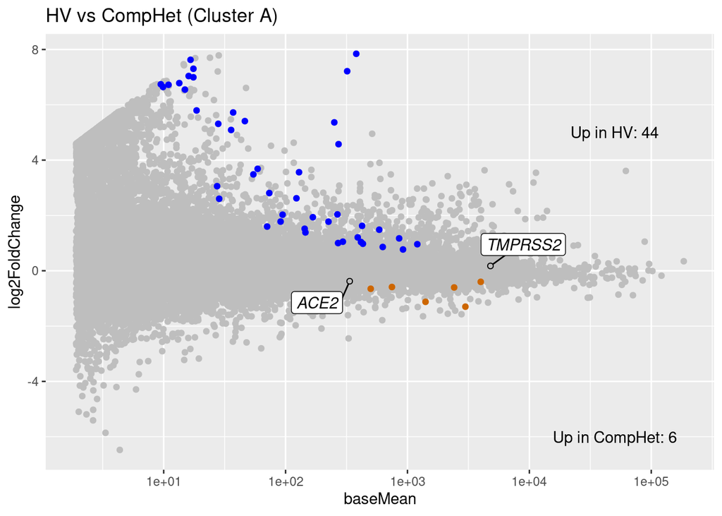

```r
ggplot(ctrl.vs.het, aes(x = baseMean, y = log2FoldChange)) +
  geom_point(aes(fill = sign, color = sign), shape = 21, stroke = 0.5) +
  geom_label_repel(
    aes(label = Gene_Name, fontface = "italic"),
    data = ace2_data,
    box.padding = 0.5,
    seed = 100,
  ) +
  geom_point(aes(fill = sign), data = ace2_data, stroke = 0.5, shape = 21) +
  scale_x_log10() +
  scale_color_manual(values = c("gray", "darkorange3", "blue"), name = "Significance", labels = c("Not significant", "Downregulated", "Upregulated")) +
  scale_fill_manual(values = c("gray", "darkorange3", "blue"), name = "Significance", labels = c("Not significant", "Downregulated", "Upregulated")) +
  annotate("text", x = 5e+04, y = 5, label = sprintf("Up in HV: %d", sum(ctrl.vs.het$sign == "Upregulated"))) +
  annotate("text", x = 5e+04, y = -6, label = sprintf("Up in CompHet: %d", sum(ctrl.vs.het$sign == "Downregulated"))) +
  ggtitle("HV vs CompHet (Cluster A)") +
  theme(legend.position = "none")
```

Save as PDF

```r
pdf("04epi-samples-control-vs-comphet.pdf", width=6, height=6)
ggplot(ctrl.vs.het, aes(x = baseMean, y = log2FoldChange)) +
  geom_point(aes(fill = sign, color = sign), shape = 21, stroke = 0.5) +
  geom_label_repel(
    aes(label = Gene_Name, fontface = "italic"),
    data = ace2_data,
    box.padding = 0.5,
    seed = 100,
  ) +
  geom_point(aes(fill = sign), data = ace2_data, stroke = 0.5, shape = 21) +
  scale_x_log10() +
  scale_color_manual(values = c("gray", "darkorange3", "blue"), name = "Significance", labels = c("Not significant", "Downregulated", "Upregulated")) +
  scale_fill_manual(values = c("gray", "darkorange3", "blue"), name = "Significance", labels = c("Not significant", "Downregulated", "Upregulated")) +
  annotate("text", x = 5e+04, y = 5, label = sprintf("Up in HV: %d", sum(ctrl.vs.het$sign == "Upregulated"))) +
  annotate("text", x = 5e+04, y = -6, label = sprintf("Up in CompHet: %d", sum(ctrl.vs.het$sign == "Downregulated"))) +
  ggtitle("HV vs CompHet (Cluster A)") +
  theme(legend.position = "none")
dev.off()
```

```r
sign.only <- ctrl.vs.het[ctrl.vs.het$padj < 0.05, ]
sign.only$gene_name <- gene_table[rownames(sign.only), "Gene_Name"]
write.csv(sign.only[order(sign.only$log2FoldChange, decreasing = TRUE), ], "04epi-ctrl-vs-het.csv")
```

### CompHet vs CF

```r
het.vs.cf <- as.data.frame(results(dds, contrast = c("genotype", "CompHet", "F508del")))
het.vs.cf <- het.vs.cf[!is.na(het.vs.cf$padj), ]
het.vs.cf$sign <- ""
het.vs.cf$sign[(het.vs.cf$log2FoldChange < 0) & (het.vs.cf$padj < 0.05)] <- "Downregulated"
het.vs.cf$sign[(het.vs.cf$log2FoldChange > 0) & (het.vs.cf$padj < 0.05)] <- "Upregulated"
het.vs.cf <- het.vs.cf[order(het.vs.cf$sign),]
```

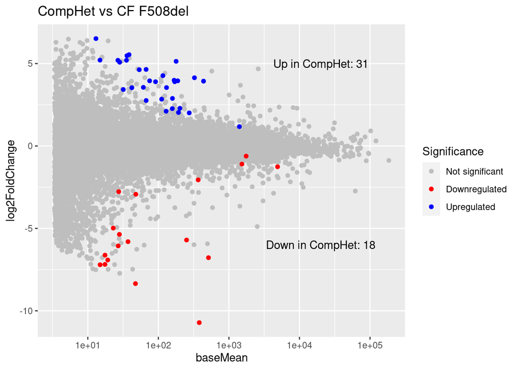

```r
ggplot(het.vs.cf) +
  geom_point(aes(x = baseMean, y = log2FoldChange, col = sign)) +
  scale_x_log10() +
  scale_color_manual(values = c("gray", "red", "blue"), name = "Significance", labels = c("Not significant", "Downregulated", "Upregulated")) +
  annotate("text", x = 2e+04, y = 5, label = sprintf("Up in CompHet: %d", sum(het.vs.cf$sign == "Upregulated"))) +
  annotate("text", x = 2e+04, y = -6, label = sprintf("Down in CompHet: %d", sum(het.vs.cf$sign == "Downregulated"))) +
  ggtitle("CompHet vs CF F508del")
```

```r
pdf("04epi-samples-comphet-vs-f508del.pdf", width=8, height=6)
ggplot(het.vs.cf) +
  geom_point(aes(x = baseMean, y = log2FoldChange, col = sign)) +
  scale_x_log10() +
  scale_color_manual(values = c("gray", "red", "blue"), name = "Significance", labels = c("Not significant", "Downregulated", "Upregulated")) +
  annotate("text", x = 2e+04, y = 5, label = sprintf("Up in CompHet: %d", sum(het.vs.cf$sign == "Upregulated"))) +
  annotate("text", x = 2e+04, y = -6, label = sprintf("Down in CompHet: %d", sum(het.vs.cf$sign == "Downregulated"))) +
  ggtitle("CompHet vs CF F508del")
dev.off()
```

```r
sign.only <- het.vs.cf[het.vs.cf$padj < 0.05, ]
sign.only$gene_name <- gene_table[rownames(sign.only), "Gene_Name"]
write.csv(sign.only[order(sign.only$log2FoldChange, decreasing = TRUE), ], "04epi-het-vs-cf.csv")
```

## IFN-1/2 signatures

```r
ifn1.genes <- read.table("HALLMARK_INTERFERON_ALPHA_RESPONSE.txt", header = FALSE, skip = 2)
ifn1.genes <- gene_table[gene_table$Gene_Name %in% ifn1.genes$V1, "Ensembl_ID"]
ifn2.genes <- read.table("HALLMARK_INTERFERON_GAMMA_RESPONSE.txt", header = FALSE, skip = 2)
ifn2.genes <- gene_table[gene_table$Gene_Name %in% ifn2.genes$V1, "Ensembl_ID"]
```

Compute means of IFN-1/2 gene sets

```r
ifn1.means <- colMeans(counts_mat_orig[ifn1.genes, ])
ifn2.means <- colMeans(counts_mat_orig[ifn2.genes, ])
```

```r
ifn1.data <- as.data.frame(colData(dds_orig))
ifn1.data$expr <- ifn1.means[rownames(ifn1.data)]
ifn1.data$genotype <- factor(ifn1.data$genotype, levels = c("HV", "CompHet", "F508del"))
```

### IFN-I

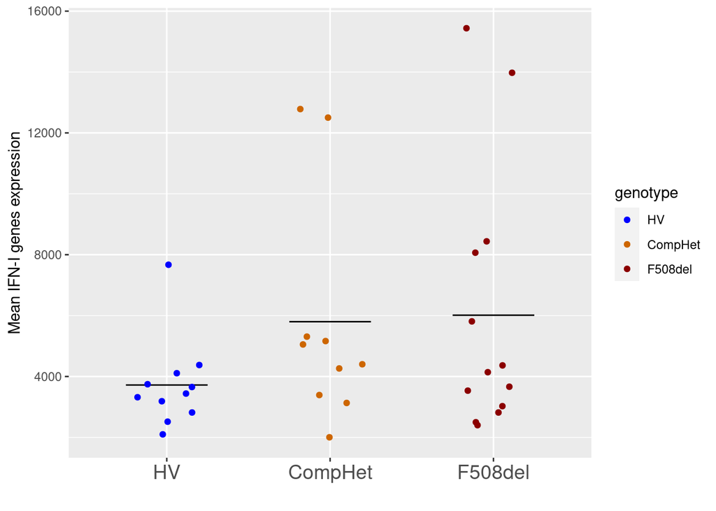

```r
ggplot(ifn1.data) +
  stat_summary(aes(x = genotype, y = expr, ymax=expr, ymin=expr), fun = "mean", geom="crossbar", width = .5, size = .2) +
  geom_jitter(aes(x = genotype, y = expr, color = genotype), width = 0.2, height = 0) +
  xlab("") + ylab("Mean IFN-I genes expression") +
  scale_color_manual(values = c("HV" = "blue", "CompHet" = "darkorange3", "F508del" = "darkred")) +
  theme(axis.text.x = element_text(size = 14))
```

Save as PDF

```r
pdf("05ifn1-expr.pdf", width = 6, height = 4)
ggplot(ifn1.data) +
  stat_summary(aes(x = genotype, y = expr, ymax=expr, ymin=expr), fun = "mean", geom="crossbar", width = .5, size = .2) +
  geom_jitter(aes(x = genotype, y = expr, color = genotype), width = 0.2, height = 0) +
  xlab("") + ylab("Mean IFN-I genes expression") +
  scale_color_manual(values = c("HV" = "blue", "CompHet" = "darkorange3", "F508del" = "darkred")) +
  theme(axis.text.x = element_text(size = 14))
dev.off()
```

Are any significant?

```r
t.test(ifn1.data$expr[ifn1.data$genotype == "HV"], ifn1.data$expr[ifn1.data$genotype == "CompHet"])
```

```
##
##  Welch Two Sample t-test
##
## data:  ifn1.data$expr[ifn1.data$genotype == "HV"] and ifn1.data$expr[ifn1.data$genotype == "CompHet"]
## t = -1.6423, df = 11.488, p-value = 0.1276
## alternative hypothesis: true difference in means is not equal to 0
## 95 percent confidence interval:
##  -4851.2687   692.8664
## sample estimates:
## mean of x mean of y
##  3720.739  5799.940
```

```r
t.test(ifn1.data$expr[ifn1.data$genotype == "HV"], ifn1.data$expr[ifn1.data$genotype == "F508del"])
```

```
##
##  Welch Two Sample t-test
##
## data:  ifn1.data$expr[ifn1.data$genotype == "HV"] and ifn1.data$expr[ifn1.data$genotype == "F508del"]
## t = -1.7915, df = 15.156, p-value = 0.0932
## alternative hypothesis: true difference in means is not equal to 0
## 95 percent confidence interval:
##  -5017.782   432.597
## sample estimates:
## mean of x mean of y
##  3720.739  6013.331
```

No

### IFN-II

```r
ifn2.data <- as.data.frame(colData(dds_orig))
ifn2.data$expr <- ifn2.means[rownames(ifn2.data)]
ifn2.data$genotype <- factor(ifn2.data$genotype, levels = c("HV", "CompHet", "F508del"))
```

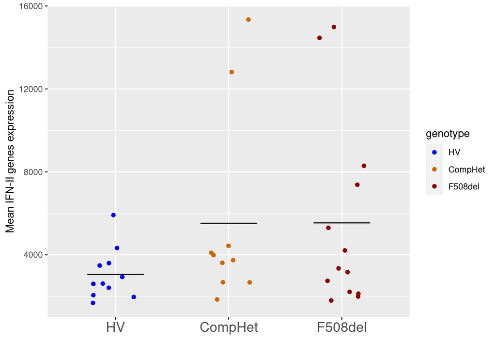

```r
ggplot(ifn2.data) +
  stat_summary(aes(x = genotype, y = expr, ymax=expr, ymin=expr), fun = "mean", geom="crossbar", width = .5, size = .2) +
  geom_jitter(aes(x = genotype, y = expr, color = genotype), width = 0.2, height = 0) +
  xlab("") + ylab("Mean IFN-II genes expression") +
  scale_color_manual(values = c("HV" = "blue", "CompHet" = "darkorange3", "F508del" = "darkred")) +
  theme(axis.text.x = element_text(size = 14))
```

Save as PDF

```r
pdf("05ifn2-expr.pdf", width = 6, height = 4)
ggplot(ifn2.data) +
  stat_summary(aes(x = genotype, y = expr, ymax=expr, ymin=expr), fun = "mean", geom="crossbar", width = .5, size = .2) +
  geom_jitter(aes(x = genotype, y = expr, color = genotype), width = 0.2, height = 0) +
  xlab("") + ylab("Mean IFN-II genes expression") +
  scale_color_manual(values = c("HV" = "blue", "CompHet" = "darkorange3", "F508del" = "darkred")) +
  theme(axis.text.x = element_text(size = 14))
dev.off()
```

Are any significant?

```r
t.test(ifn2.data$expr[ifn2.data$genotype == "HV"], ifn2.data$expr[ifn2.data$genotype == "CompHet"])
```

```
##
##  Welch Two Sample t-test
##
## data:  ifn2.data$expr[ifn2.data$genotype == "HV"] and ifn2.data$expr[ifn2.data$genotype == "CompHet"]
## t = -1.6397, df = 10.167, p-value = 0.1316
## alternative hypothesis: true difference in means is not equal to 0
## 95 percent confidence interval:
##  -5818.2885   878.8725
## sample estimates:
## mean of x mean of y
##  3052.686  5522.394
```

No.

## Group IFN-1/2 expression by k-means clusters

```r
ifn1.data$cluster <- factor(group.names[kmeans.groups], levels = c("A", "B", "C"))
```

### IFN-I

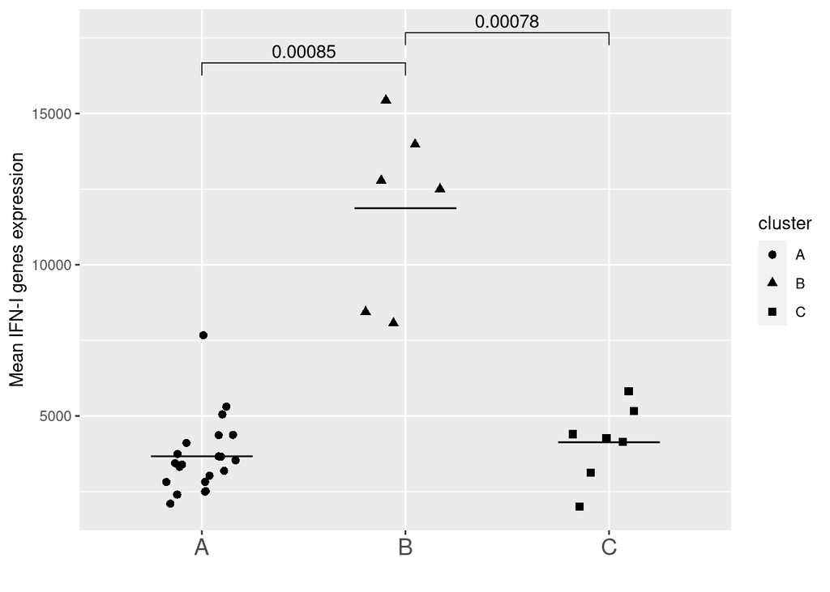

```r
ggplot(ifn1.data, aes(x = cluster, y = expr, shape = cluster)) +
  stat_summary(aes(ymax = expr, ymin = expr), fun = "mean", geom="crossbar", width = .5, size = .2) +
  geom_jitter(width = 0.2, height = 0, size = 2) +
  xlab("") + ylab("Mean IFN-I genes expression") +
  stat_compare_means(
    comparisons = list(c("A", "B"), c("B", "C")),
    label.y = c(16000, 17000),
    method = "t.test"
  ) +
  theme(axis.text.x = element_text(size = 14))
```

Save as PDF

```r
pdf("06ifn1-expr-by-cluster.pdf", width = 6, height = 4)
ggplot(ifn1.data, aes(x = cluster, y = expr, shape = cluster)) +
  stat_summary(aes(ymax = expr, ymin = expr), fun = "mean", geom="crossbar", width = .5, size = .2) +
  geom_jitter(width = 0.2, height = 0, size = 2) +
  xlab("") + ylab("Mean IFN-I genes expression") +
  stat_compare_means(
    comparisons = list(c("A", "B"), c("B", "C")),
    label.y = c(16000, 17000),
    method = "t.test"
  ) +
  theme(axis.text.x = element_text(size = 14))
dev.off()
```

### IFN-II

```r
ifn2.data$cluster <- factor(group.names[kmeans.groups], levels = c("A", "B", "C"))
```

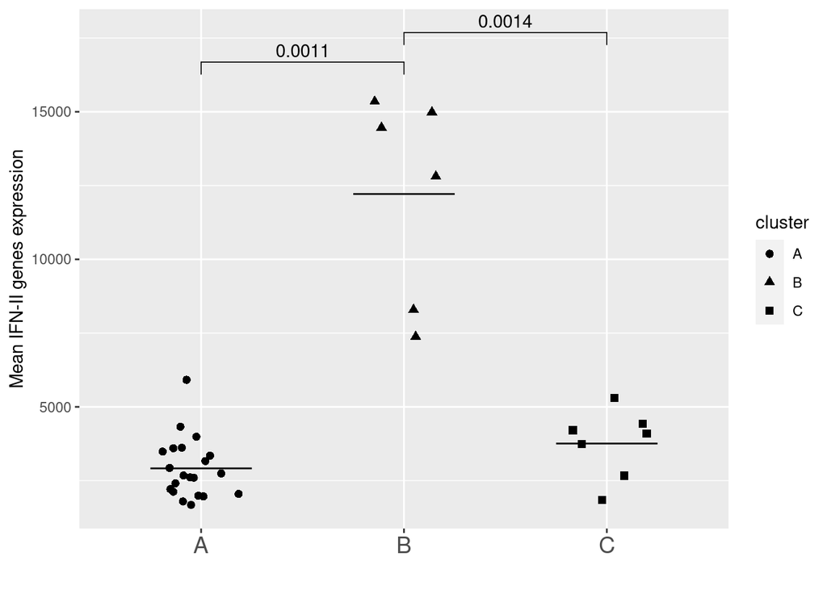

```r
ggplot(ifn2.data, aes(x = cluster, y = expr, shape = cluster)) +
  stat_summary(aes(ymax = expr, ymin = expr), fun = "mean", geom="crossbar", width = .5, size = .2) +
  geom_jitter(width = 0.2, height = 0, size = 2) +
  xlab("") + ylab("Mean IFN-II genes expression") +
  stat_compare_means(
    comparisons = list(c("A", "B"), c("B", "C")),
    label.y = c(16000, 17000),
    method = "t.test"
  ) +
  theme(axis.text.x = element_text(size = 14))
```

Save as PDF

```r
pdf("06ifn2-expr-by-cluster.pdf", width = 6, height = 4)
ggplot(ifn2.data, aes(x = cluster, y = expr, shape = cluster)) +
  stat_summary(aes(ymax = expr, ymin = expr), fun = "mean", geom="crossbar", width = .5, size = .2) +
  geom_jitter(width = 0.2, height = 0, size = 2) +
  xlab("") + ylab("Mean IFN-II genes expression") +
  stat_compare_means(
    comparisons = list(c("A", "B"), c("B", "C")),
    label.y = c(16000, 17000),
    method = "t.test"
  ) +
  theme(axis.text.x = element_text(size = 14))
dev.off()
```